# Math250 Dec 5 BerlinI Anova HW

```r
library(tidyverse)
library(readxl)
library(broom)
```

### Problem 1

> Does this sample data provide evidence that sepal width is dependent on species in the population from which this sample is drawn? Test at significance level $ = 0.05 $

We want to know if the knowing the species of an iris will give us any information about it’s sepal width. The null hypothesis $H_0$ suggests that the mean `Sepal.Width` is the same for all species. The alternative hypothesis $H_a$ suggests that the mean `Sepal.Width` is not the same for all species of iris.

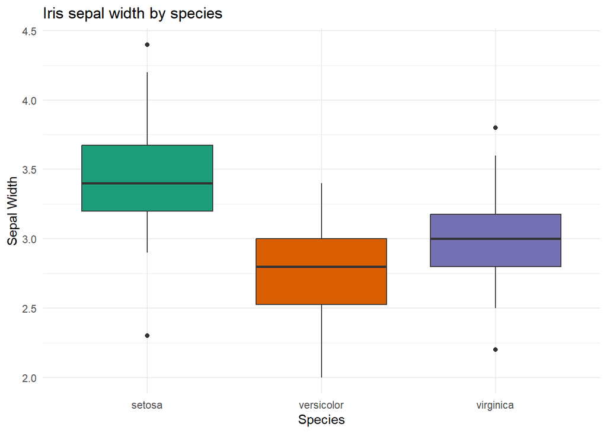

```r
iris %>%
  ggplot(aes(x = Species,
             y = Sepal.Width,
             fill = Species)) +
  geom_boxplot(show.legend = FALSE) +
  theme_minimal() +
  scale_fill_brewer(palette = "Dark2") +
  labs(y = "Sepal Width",
       title = "Iris sepal width by species")
```

```r
sepal_anova <- aov(Sepal.Width ~ Species,
                   data = iris)

summary(sepal_anova)
```

```
             Df Sum Sq Mean Sq F value Pr(>F)
Species       2  11.35   5.672   49.16 <2e-16 ***
Residuals   147  16.96   0.115
---
Signif. codes:  0 '***' 0.001 '**' 0.01 '*' 0.05 '.' 0.1 ' ' 1
```

A p-values of $2 \times 10 ^{-16}$ gives evidence against the null hypothesis. This suggests that the mean sepal width is not the same for all species so there is evidence that sepal width is not independent from species.

### Problem 2

> Follow up on problem 1 by comparing mean sepal widths pairwise across different species using the post-hoc test covered in class.

```r
TukeyHSD(sepal_anova)
```

```
  Tukey multiple comparisons of means
    95% family-wise confidence level

Fit: aov(formula = Sepal.Width ~ Species, data = iris)

$Species
                       diff         lwr        upr     p adj
versicolor-setosa    -0.658 -0.81885528 -0.4971447 0.0000000
virginica-setosa     -0.454 -0.61485528 -0.2931447 0.0000000
virginica-versicolor  0.204  0.04314472  0.3648553 0.0087802
```

The Tukey Honest Standard Differences Test suggests that there is good evidence that the species versicolor and setosa, as well as the species virginica and setosa, have different mean sepal width. There is also evidence that the species virginica and versicolor have different mean sepal widths, however is is slightly weaker.

### Problem 3

> Is sepal width a statisticaly significant explainer of petal width? Follow all best-practices from class.

To check is the sepal width explains petal width, we will check if they have a linear relationship. The null$H_0$ is that there is no linear relationship between the variables `Sepal.Width` and `Petal.Width`. The alternative hypothesis is that $H_a$ there is a linear relationship between the two variables.

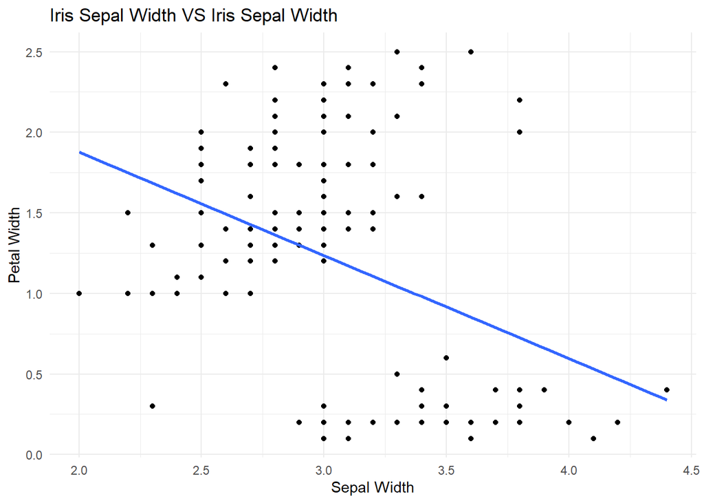

```r
iris %>%
  ggplot(aes(x = Sepal.Width,
             y = Petal.Width)) +
  geom_point() +
  geom_smooth(method = 'lm',
              se = FALSE) +
  theme_minimal() +
  labs(x = "Sepal Width",
       y = "Petal Width",
       title = "Iris Sepal Width VS Iris Sepal Width")
```

```r
sepal_pedal_model <- lm(Petal.Width ~ Sepal.Width,
                        data = iris)

summary(sepal_pedal_model)
```

```
Call:
lm(formula = Petal.Width ~ Sepal.Width, data = iris)

Residuals:
     Min       1Q   Median       3Q      Max
-1.38424 -0.60889 -0.03208  0.52691  1.64812

Coefficients:
            Estimate Std. Error t value Pr(>|t|)
(Intercept)   3.1569     0.4131   7.642 2.47e-12 ***
Sepal.Width  -0.6403     0.1338  -4.786 4.07e-06 ***
---
Signif. codes:  0 '***' 0.001 '**' 0.01 '*' 0.05 '.' 0.1 ' ' 1

Residual standard error: 0.7117 on 148 degrees of freedom
Multiple R-squared:  0.134, Adjusted R-squared:  0.1282
F-statistic: 22.91 on 1 and 148 DF,  p-value: 4.073e-06
```

### Problem 4

> Construct a parallel-slopes model explaining petal width with sepal width and species. Write the equation of the model, making sure the meanings of your variables are clear. Also include a plot.

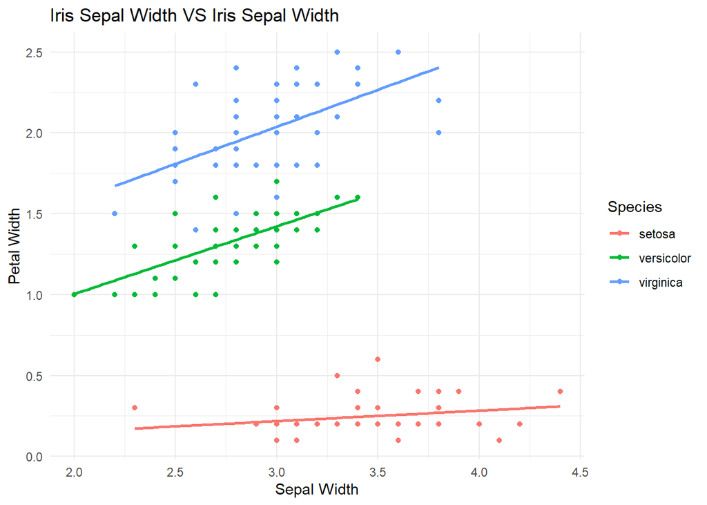

```r
iris %>%
  ggplot(aes(x = Sepal.Width,
             y = Petal.Width,
             color = Species)) +
  geom_point() +
  geom_smooth(method = 'lm',
              se = FALSE) +
  theme_minimal() +
  labs(x = "Sepal Width",
       y = "Petal Width",
       title = "Iris Sepal Width VS Iris Sepal Width")
```

```r
model_par <- lm(Petal.Width ~ Sepal.Width + Species,
                data = iris)

summary(model_par)
```

```
Call:
lm(formula = Petal.Width ~ Sepal.Width + Species, data = iris)

Residuals:
     Min       1Q   Median       3Q      Max
-0.51998 -0.09476 -0.01406  0.10161  0.42333

Coefficients:
                  Estimate Std. Error t value Pr(>|t|)
(Intercept)       -0.72577    0.15298  -4.744 4.94e-06 ***
Sepal.Width        0.28348    0.04400   6.443 1.59e-09 ***
Speciesversicolor  1.26653    0.04638  27.306  < 2e-16 ***
Speciesvirginica   1.90870    0.04138  46.127  < 2e-16 ***
---
Signif. codes:  0 '***' 0.001 '**' 0.01 '*' 0.05 '.' 0.1 ' ' 1

Residual standard error: 0.1812 on 146 degrees of freedom
Multiple R-squared:  0.9446,    Adjusted R-squared:  0.9435
F-statistic: 830.2 on 3 and 146 DF,  p-value: < 2.2e-16
```

### Problem 5

> Construct an attractive residual plot for the model in the last problem. Comment on any patterns that you observe.

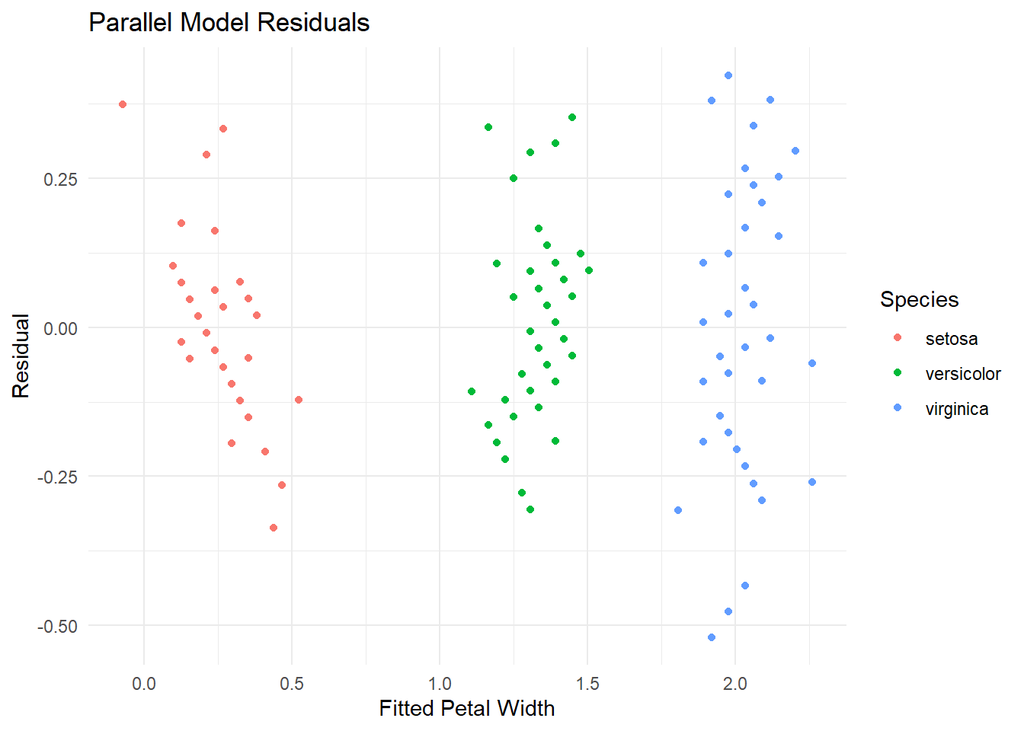

```r
model_par_aug <- augment(model_par)

model_par_aug %>%
  ggplot(aes(x = .fitted,
             y = .resid,
             color = Species)) +
  geom_point() +
  theme_minimal()+
  labs(x = "Fitted Petal Width",
       y = "Residual",
       title = "Parallel Model Residuals")
```